# Emissions around the World

Arthur Esenaliev

2023-09-22

# **Intoduction**

This report is about the kilotons of greenhouse gas emissions from chemical pollutants nitrous oxide and carbon dioxide around the world in 2018. The data was collected with concentrations of Carbon Dioxide and other greenhouse gases in the atmosphere. The emissions dataset<sup>1</sup> contains the variables:

| Variable Name | Description |
| --- | --- |
| Year | The year data was collected (2018) |
| Country | Country data was collected |
| Region | World region of the country |
| GDP | Gross Domestic Product of the country |
| Population | Population of the country |
| N2O_Produced | Amount of nitrous oxide produced |
| CO2_Produced | Amount of carbon dioxide produced |

<sup>1</sup> Sourced from Our World in Data and and retrieved from CORGIS Dataset Project:

- https://ourworldindata.org/co2-and-greenhouse-gas-emissions
- https://corgis-edu.github.io/corgis/csv/global_emissions/

The variable that is the chosen outcome is the amount of Carbon Dioxide produced, or CO2_Produced. To investigate this, we will be comparing predictors Population, GDP, and Nitrous Oxide Produced.

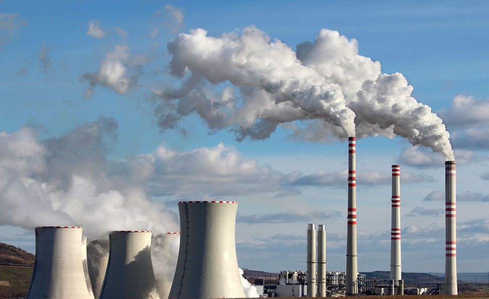

Source: https://static.scientificamerican.com/sciam/cache/file/D7123FA9-E46F-474F-A6CC21231555057D_source.jpg

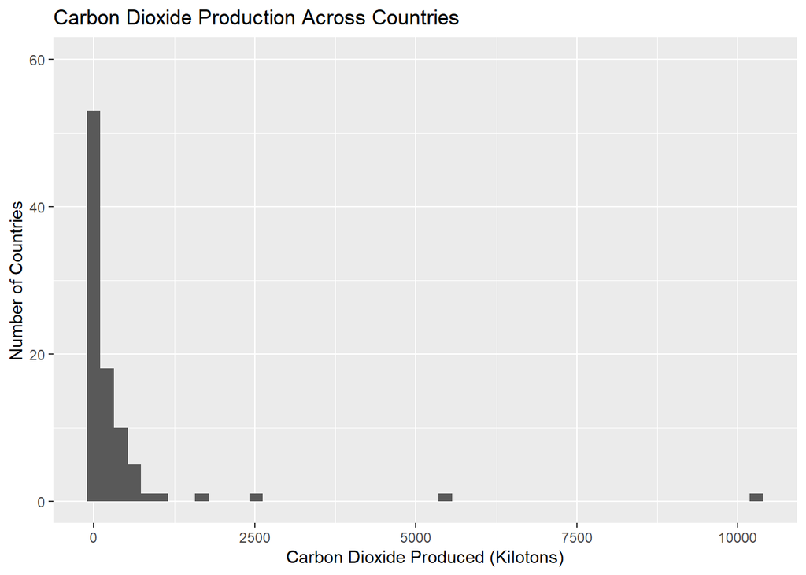

The univariate histogram above shows the number of countries producing in each range of CO2 kilotons. The data contains an outlier, which is China. Also, the mean (average) kilotons of CO2 Produced in each country is 372.09 and the standard deviation is 1231.29. The data distribution is primarily right skewed.

### **Predictor graph 1**

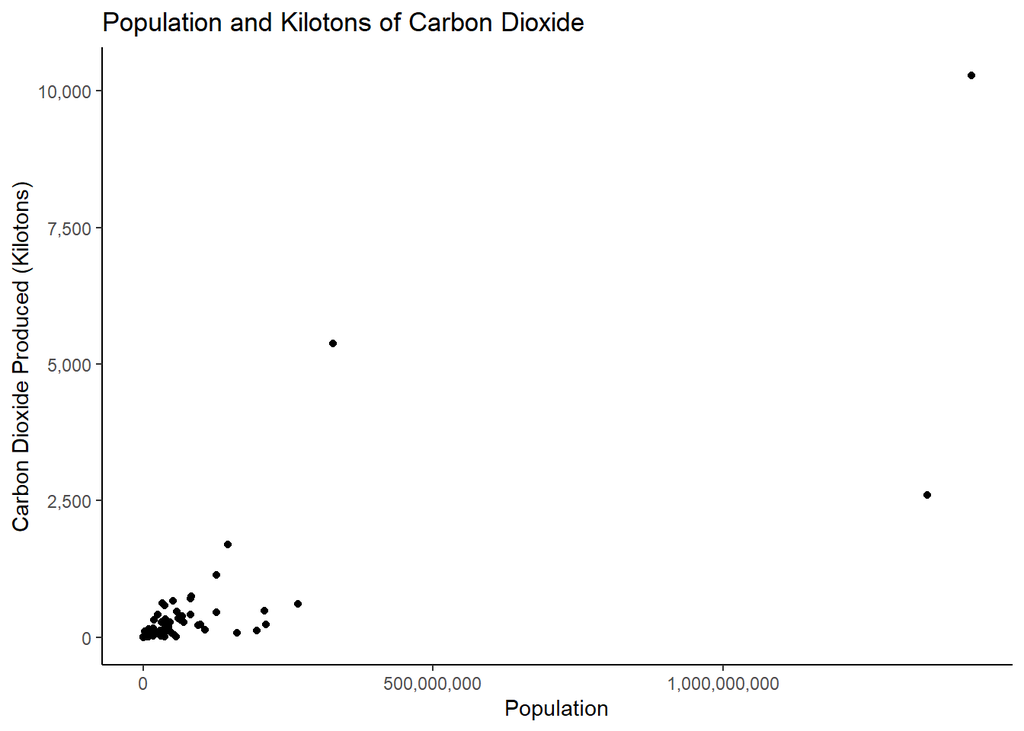

The bivariate scatterplot above shows the relationship between the populations of each country and the kilotons of Carbon Dioxide the country produces. The relationship correlation between the two variables can be used with correlation coefficient r, which is 0.81. This shows a strong positive correlation, considering the correlation coefficient being close to 1, as well as the graph showing a positive relationship between the two variables. So, the greater the population of a country, the more carbon dioxide is produced, according to the correlation coefficient and graph. Additionally noted, there are many points clustered toward the bottom left, so there are many countries with lower amounts of population and kilotons of CO2 produced.

### **Predictor Graph 2**

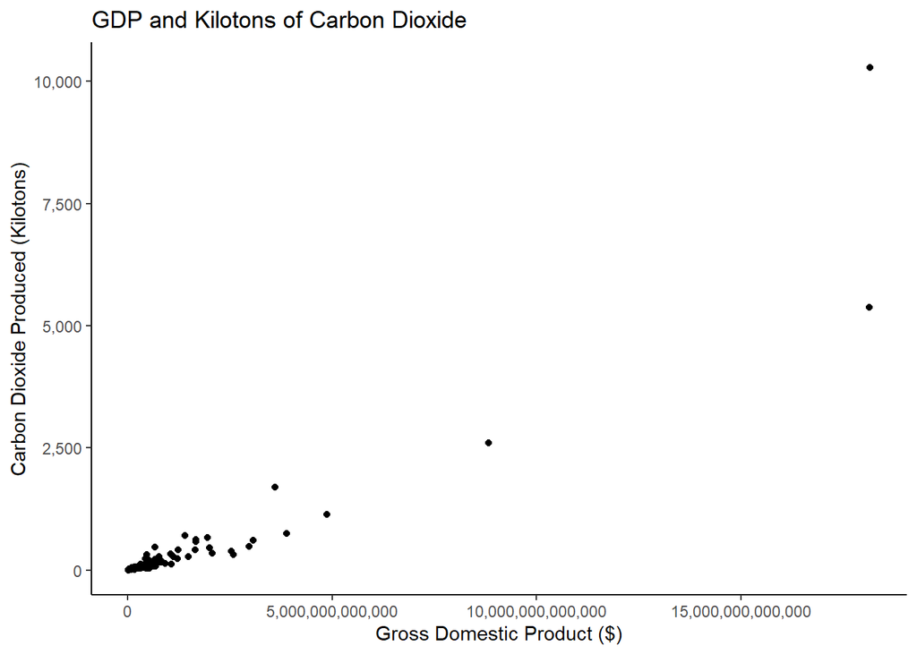

The bivariate scatterplot above shows the relationship between the Gross Domestic Product of each country and the kilotons of Carbon Dioxide the country produces. The relationship correlation between the two variables can be used with correlation coefficient r, which is 0.94. This shows a very strong positive correlation, considering the correlation coefficient being very close to 1, as well as the graph showing a positive relationship between the two variables. With that, the higher the GDP the country has, the more CO2 it produces. Additionally noted, there are many points clustered toward the bottom left, so there are many countries with lower GDP’s and kilotons of CO2 produced.

### **Predictor Graph 3**

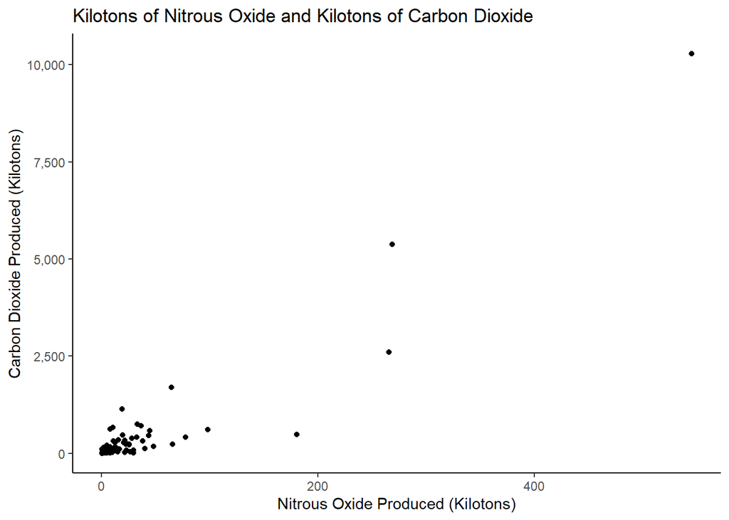

The bivariate scatterplot above shows the relationship between the kilotons of Nitrous Oxide Produced in each country and the kilotons of Carbon Dioxide the country produces. The relationship correlation between the two variables can be used with correlation coefficient r, which is 0.93. This shows a very strong positive correlation, considering the correlation coefficient being close to 1, as well as the graph showing a very strong positive relationship between the two variables. Thus, the higher the amount of Nitrous Oxide is produced, the higher the amount of carbon dioxide is produced. Additionally noted, there are many points clustered toward the bottom left, so there are many countries with lower amounts of N2O Produced and kilotons of CO2 produced.

### Conclusion

From the findings, we can see that population, GDP, and emissions of other greenhouse gases like N2O influence the amount of carbon dioxide emitted across countries in the world. Specifically, the countries that are larger and more industrialized have greater emission levels. That being said, the countries with lower predictors (Population, GDP, N2O_Produced), the lower the amount of CO2 is produced. The greater each of these predictors, the more CO2 is produced. Thus, countries with greater population tend to produce more CO2 than smaller populated countries. The larger the GDP a country has, the more industrialized it is, so there are more factories emitting carbon dioxide into the atmosphere. Same thing with N2O, the more that the pollutant is emitted, the more likely CO2 is emitted. Some areas for further research could be by studying other greenhouse gases, like methane, or by analyzing the effects other predictors have on the emissions of greenhouse gases, like each country’s land area or population density.

#### **References**

- ALPERIN, BRYEN. “Understanding Scope 1, 2, & 3 Emissions: How You Can Reduce Your Emissions With Tax Credits.” Foss & Co, 7 Oct. 2022, fossandco.com/news/understanding-scope-123-emissions/.
- Ritchie, Hannah, et al. “CO₂ and Greenhouse Gas Emissions.” Our World in Data, 11 May 2020, ourworldindata.org/co2-and-greenhouse-gas-emissions.
- “Global Emissions CSV File.” CORGIS Datasets Project, corgis-edu.github.io/corgis/csv/global_emissions/. Accessed 22 Sept. 2023.